# PAGA_Tutorial_Cellcraft

**PAGA Pseudotime Tutorial - (ii) generation of TENET inputs**

This tutorial serves as the foundational module for producing the input files required for **TENET** gene regulatory network (GRN) analysis.

*Structure.* The tutorial comprises two modules: (i) **preprocessing** and (ii) **generation of TENET inputs**. This page covers Module (ii), demonstrating pseudotime construction and TENET input generation.

### What you need (TENET inputs)

1. Pseudotime matrix: rows = cells; one or more pseudotime trajectories (numeric).
2. Cell-by-gene expression matrix: rows = cells; columns = genes; normalized/log-scaled counts recommended.
3. Cell-selection file: list or annotation of cells to include (e.g., a subset/trajectory).

### How to generate them

- Seurat → Monocle (R)  
  Outline: convert Seurat → Monocle, compute trajectory, export pseudotime, export expression matrix for selected cells, write a cell list.
- Scanpy → PAGA (Python)  
  Outline: compute neighbors/UMAP → PAGA/trajectory, extract pseudotime (diffusion/DF), subset cells, export expression matrix and cell list.

# Index

**1. Setting up from Scanpy Object**  
**1-1. Setting Up the Environment**  
**1-2. Load Data from Scanpy Result Data**

**2. Visualization**  
**2-1. Simple Visualization**  
**2-2. Denoising the Graph in Diffusion map**

**3. Constructing the pseudotime and PAGA**  
**3-1. PAGA**  
**3-2. Pseudotime**

**4. Prepare Tenet Input**  
___

## 1. Setting up from Scanpy Object

Return to Index

The goal of this process is to calculate pseudotime and ultimately create the input for Tenet. There is no QC or normalization process as we are building upon the previous Scanpy results. For information on Scanpy, please refer to this **[LINK](https://scanpy-tutorials.readthedocs.io/en/latest/pbmc3k.html)**.

___

### 1-1. Setting Up the Environment

```python
import numpy as np
import pandas as pd
import scanpy as sc
import matplotlib.pyplot as pl
from matplotlib import rcParams
import warnings
warnings.filterwarnings("ignore")
```

Set the verbosity level and configure the resolution, size, style, and format of the figures. Dpi means dots per inch and Low Dpi yields small inline figures.

```python
sc.settings.verbosity = 3
sc.logging.print_versions()
sc.settings.set_figure_params(dpi=80, frameon=False, facecolor='white', figsize=(3, 3))
```

[output not shown]

[output cut: 61 more lines]

[output not shown]

### 1-2. Load Data from Scanpy Result Data

Proceed using the results file **from Scanpy**. Normalization and clustering have already been performed.

```python
adata = sc.read_h5ad('/home/Users/write/pbmc3k.h5ad')
```

```python
adata
```

```
AnnData object with n_obs × n_vars = 2638 × 1838
    obs: 'n_genes', 'n_genes_by_counts', 'total_counts', 'total_counts_mt', 'pct_counts_mt', 'leiden'
    var: 'gene_ids', 'n_cells', 'mt', 'n_cells_by_counts', 'mean_counts', 'pct_dropout_by_counts', 'total_counts', 'highly_variable', 'means', 'dispersions', 'dispersions_norm', 'mean', 'std'
    uns: 'dendrogram_leiden', 'hvg', 'leiden', 'leiden_colors', 'log1p', 'neighbors', 'pca', 'rank_genes_groups', 'umap'
    obsm: 'X_pca', 'X_umap'
    varm: 'PCs'
    layers: 'counts'
    obsp: 'connectivities', 'distances'
```

## 2. Visualization

Return to Index

Utilize visualization tools to understand the cellular relationships and transitions.

___

### 2-1. Simple Visualization

```
drawing single-cell graph using layout 'fa'
    finished: added
    'X_draw_graph_fa', graph_drawing coordinates (adata.obsm) (0:00:09)
```

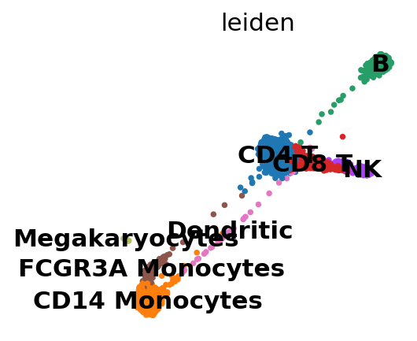

```python
sc.tl.draw_graph(adata)
sc.pl.draw_graph(adata, color='leiden', legend_loc='on data')
```

### 2-2. Denoising the Graph in Diffusion map

This step is **not necessary but helps to denoise** the graph by computing distances within a few diffusion components. We use a few of the first spectral components to denoise the data. It is similar to PCA-based denoising.

```python
sc.tl.diffmap(adata)
sc.pp.neighbors(adata, n_neighbors=10, use_rep='X_diffmap')
```

```
computing Diffusion Maps using n_comps=15(=n_dcs)
computing transitions
    finished (0:00:00)
    eigenvalues of transition matrix
    [1.         0.99624944 0.99259275 0.9800847  0.9690868  0.9543348
     0.9410093  0.87107414 0.8574794  0.8273053  0.81189257 0.80565023
     0.79537004 0.78257203 0.761363  ]
    finished: added
    'X_diffmap', diffmap coordinates (adata.obsm)
    'diffmap_evals', eigenvalues of transition matrix (adata.uns) (0:00:00)
computing neighbors
    finished: added to `.uns['neighbors']`
    `.obsp['distances']`, distances for each pair of neighbors
    `.obsp['connectivities']`, weighted adjacency matrix (0:00:05)
```

```
drawing single-cell graph using layout 'fa'
    finished: added
    'X_draw_graph_fa', graph_drawing coordinates (adata.obsm) (0:00:09)
```

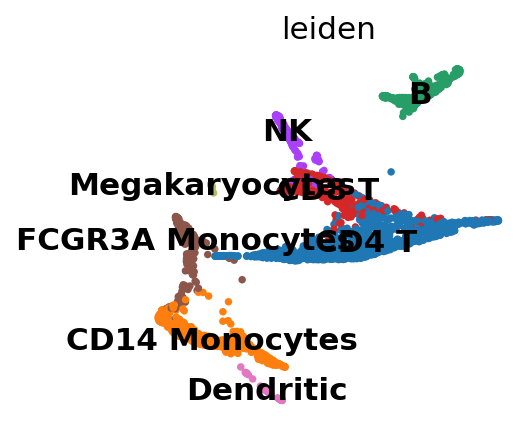

```python
sc.tl.draw_graph(adata)
sc.pl.draw_graph(adata, color='leiden', legend_loc='on data')
```

## 3. Constructing the pseudotime and PAGA

Return to Index

After calculating PAGA, we proceed to calculate pseudotime. The goal of this tutorial is to create the Tenet input, and pseudotime is part of this. Therefore, running PAGA is optional. For detailed information about PAGA, please refer to the **[LINK](https://scanpy.readthedocs.io/en/stable/generated/scanpy.tl.paga.html)**.

___

### 3-1. PAGA

PAGA **(Partition-based Graph Abstraction)** represents cell-to-cell relationships as a graph, highlighting connections and interactions between different cell types. Interpreting the PAGA graph provides insights into cell relationships and system-level properties within the dataset.

The data we are using may not result in a beautifully drawn PAGA graph. Therefore, we have not plotted the graph. However, if you wish to visualize the graph, please erase the following code.

> - `plot = False`

```python
sc.tl.paga(adata, groups='leiden')
sc.pl.paga(adata, color=['leiden'], plot = False)
```

```
running PAGA
    finished: added
    'paga/connectivities', connectivities adjacency (adata.uns)
    'paga/connectivities_tree', connectivities subtree (adata.uns) (0:00:00)
--> added 'pos', the PAGA positions (adata.uns['paga'])
```

```
drawing single-cell graph using layout 'fa'
    finished: added
    'X_draw_graph_fa', graph_drawing coordinates (adata.obsm) (0:00:08)
```

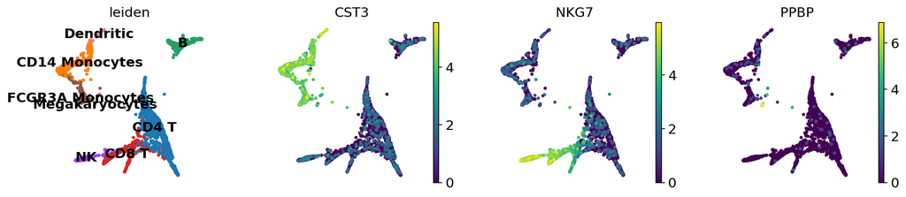

```python
sc.tl.draw_graph(adata, init_pos='paga')
sc.pl.draw_graph(adata, color=['leiden', 'CST3', 'NKG7', 'PPBP'], legend_loc='on data')
```

You can specify and apply the colors through the following steps to give visualization.

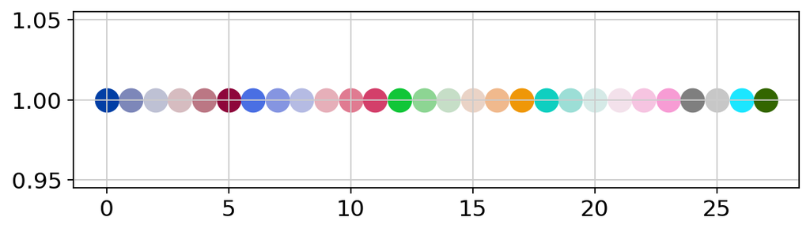

```python
pl.figure(figsize=(8, 2))
for i in range(28):
    pl.scatter(i, 1, c=sc.pl.palettes.zeileis_28[i], s=200)
pl.show()
```

```python
zeileis_colors = np.array(sc.pl.palettes.zeileis_28)
new_colors = np.array(adata.uns['leiden_colors'])
```

```python
new_colors[0] = zeileis_colors[12]  # CD4 T colors / green
new_colors[1] = zeileis_colors[17]  # CD14 Monocytes colors
new_colors[2] = zeileis_colors[27]  # B colors
new_colors[3] = zeileis_colors[13]  # CD8 T colors
new_colors[4] = zeileis_colors[14]  # NK colors
new_colors[5] = zeileis_colors[16]  # FCGR3A Monocytes colors
new_colors[6] = zeileis_colors[23]  # Dendritic colors
new_colors[7] = zeileis_colors[15]  # Megakaryocytes colors
```

```python
adata.uns['leiden_colors'] = new_colors
```

```
--> added 'pos', the PAGA positions (adata.uns['paga'])
WARNING: saving figure to file figures/paga_compare.pdf
```

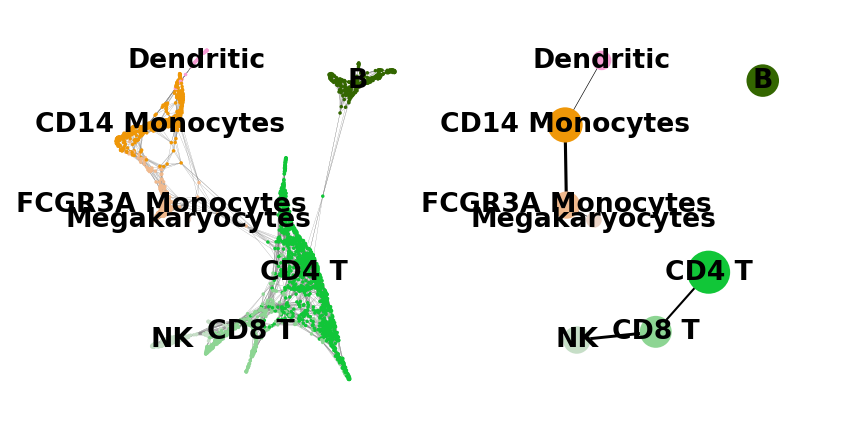

```python
sc.pl.paga_compare(
    adata, threshold=0.03, title='', right_margin=0.2, size=10, edge_width_scale=0.5,
    legend_fontsize=12, fontsize=12, frameon=False, edges=True, save=True)
```

### 3-2. Pseudotime

Predict the **Differentiation** process from the root region using trajectory calculations. In our data, we arbitrarily set initiating from CD4 T cells. If you want another initiating cell, change it.

```python
adata.uns['iroot'] = np.flatnonzero(adata.obs['leiden']  == 'CD4 T')[0]
```

```
computing Diffusion Pseudotime using n_dcs=10
    finished: added
    'dpt_pseudotime', the pseudotime (adata.obs) (0:00:00)
```

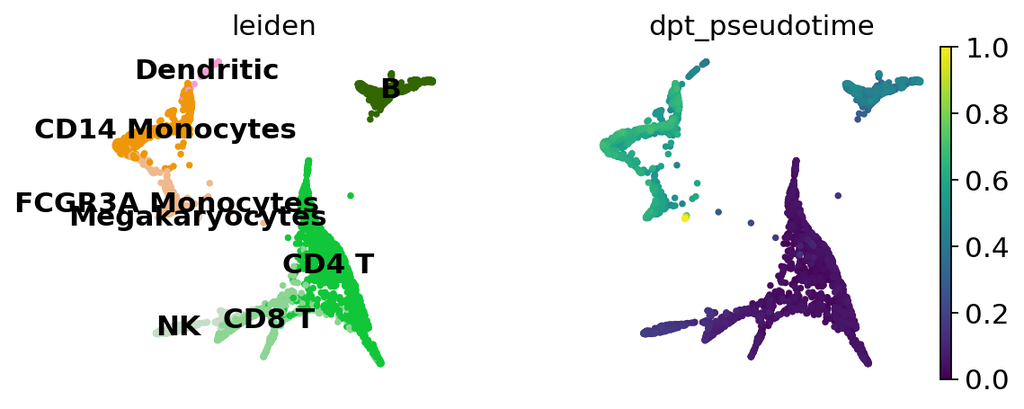

```python
sc.tl.dpt(adata)
sc.pl.draw_graph(adata, color=['leiden', 'dpt_pseudotime'], legend_loc='on data')
```

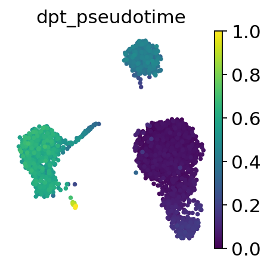

```python
sc.pl.umap(adata,color='dpt_pseudotime')
```

## 4. Prepare Tenet Input

Return to Index

Here, we use the Raw count matrix, which was prepared separately during the Scanpy process. Regarding the Cell-Gene matrix, there is one assumption: we will **use all cells**. Therefore, we need select the genes we want to use. And pseudotime is already calculated in previous code.

___

This is Raw Count matrix.

```python
DEG_raw_count_matrix = pd.read_csv('/home/Users/write/DEG_raw_count_matrix.csv'
                                   , index_col = 0)
DEG_raw_count_matrix
```

|  | RPS12 | LYZ | CD74 | CCL5 | NKG7 | LST1 | HLA-DPA1 | PF4 | LDHB | S100A9 | ... | HTATIP2 | MYEOV2 | OTUB1 | SHFM1 | NEURL1 | ARHGAP4 | CTNNBL1 | TLE4 | ERICH1 | DECR1 |
| --- | --- | --- | --- | --- | --- | --- | --- | --- | --- | --- | --- | --- | --- | --- | --- | --- | --- | --- | --- | --- | --- |
| AAACATACAACCAC-1 | 37.0 | 1.0 | 1.0 | 18.0 | 0.0 | 0.0 | 0.0 | 0.0 | 5.0 | 0.0 | ... | 0.0 | 1.0 | 0.0 | 0.0 | 0.0 | 0.0 | 0.0 | 0.0 | 0.0 | 0.0 |
| AAACATTGAGCTAC-1 | 60.0 | 3.0 | 51.0 | 1.0 | 1.0 | 0.0 | 13.0 | 0.0 | 6.0 | 0.0 | ... | 0.0 | 1.0 | 0.0 | 1.0 | 0.0 | 0.0 | 2.0 | 0.0 | 0.0 | 1.0 |
| AAACATTGATCAGC-1 | 10.0 | 2.0 | 2.0 | 0.0 | 0.0 | 0.0 | 0.0 | 0.0 | 9.0 | 0.0 | ... | 0.0 | 0.0 | 0.0 | 0.0 | 0.0 | 0.0 | 0.0 | 0.0 | 0.0 | 0.0 |
| AAACCGTGCTTCCG-1 | 15.0 | 24.0 | 14.0 | 0.0 | 1.0 | 5.0 | 4.0 | 0.0 | 0.0 | 12.0 | ... | 0.0 | 0.0 | 0.0 | 0.0 | 0.0 | 0.0 | 0.0 | 0.0 | 0.0 | 0.0 |
| AAACCGTGTATGCG-1 | 1.0 | 0.0 | 1.0 | 3.0 | 11.0 | 0.0 | 2.0 | 0.0 | 0.0 | 0.0 | ... | 0.0 | 0.0 | 0.0 | 0.0 | 0.0 | 0.0 | 0.0 | 0.0 | 0.0 | 0.0 |
| ... | ... | ... | ... | ... | ... | ... | ... | ... | ... | ... | ... | ... | ... | ... | ... | ... | ... | ... | ... | ... | ... |
| TTTCGAACTCTCAT-1 | 22.0 | 64.0 | 21.0 | 0.0 | 1.0 | 3.0 | 5.0 | 0.0 | 0.0 | 96.0 | ... | 0.0 | 1.0 | 0.0 | 0.0 | 0.0 | 1.0 | 0.0 | 0.0 | 1.0 | 1.0 |
| TTTCTACTGAGGCA-1 | 8.0 | 0.0 | 13.0 | 0.0 | 0.0 | 0.0 | 3.0 | 0.0 | 2.0 | 0.0 | ... | 0.0 | 0.0 | 0.0 | 2.0 | 0.0 | 0.0 | 0.0 | 1.0 | 0.0 | 0.0 |
| TTTCTACTTCCTCG-1 | 14.0 | 0.0 | 30.0 | 0.0 | 0.0 | 0.0 | 3.0 | 0.0 | 0.0 | 1.0 | ... | 0.0 | 0.0 | 0.0 | 0.0 | 0.0 | 0.0 | 0.0 | 0.0 | 1.0 | 0.0 |
| TTTGCATGAGAGGC-1 | 3.0 | 0.0 | 33.0 | 0.0 | 0.0 | 0.0 | 8.0 | 0.0 | 0.0 | 0.0 | ... | 0.0 | 0.0 | 1.0 | 0.0 | 0.0 | 0.0 | 0.0 | 0.0 | 0.0 | 0.0 |
| TTTGCATGCCTCAC-1 | 19.0 | 1.0 | 0.0 | 0.0 | 0.0 | 0.0 | 0.0 | 0.0 | 4.0 | 1.0 | ... | 0.0 | 0.0 | 0.0 | 0.0 | 0.0 | 0.0 | 0.0 | 0.0 | 0.0 | 0.0 |

2638 rows × 1627 columns

Create Tenet Input.

```python
def TENET_input_make(adata, directory='/home/Users/write'):
    # Set 'cell_select' column to '1' for all observations
    adata.obs['cell_select'] = '1'

    # Extract the required columns
    input_data = adata.obs[['dpt_pseudotime', 'cell_select']]

    # Save pseudotime to a CSV file
    input_data['dpt_pseudotime'].to_csv(f'{directory}/pseudotime.csv', index=False, header=False)

    # Save cell_select to a CSV file
    input_data['cell_select'].to_csv(f'{directory}/cell_select.csv', index=False, header=False)
```

```python
TENET_input_make(adata)
```